# demo1

Ville Laitinen

5 3 2019

# Getting started

- Define variables:

```r
smallnum <- 4
bignum <- 124
```

- Check contents of environment:

```r
ls()
```

```
## [1] "bignum"   "smallnum"
```

- Environment can be cleaned with `rm(list=ls())`.

```r
# some basic operations
smallnum + bignum
```

```
## [1] 128
```

```r
bignum/smallnum
```

```
## [1] 31
```

- In R code hash (#) is used for comments.
- Sourcing doesn’t print the commands to console resulting in a tidyer R experience.
- History tab contain all commands run in console.

## Vectors, matrices and data frames

- Define some vectors:

```r
examplevector1 <- c(2, 4, 9, 5)
examplevector2 <- 1:25
examplevector3 <- seq(1,9,length=100)
examplevector4 <- seq(0,2*pi,by=pi/8)
```

- Access the first six elements of vector with `head()`

```r
head(examplevector3)
```

```
## [1] 1.000000 1.080808 1.161616 1.242424 1.323232 1.404040
```

- Define some matrices:

```r
examplematrix1 <- matrix(c(-1,2,3,1),nrow=2,ncol=2)
examplematrix2 <- matrix(1:12,nrow=3)
examplematrix3 <- t(examplematrix2)
```

- Matrices are stored as data, vectors as values in the environment.
- Elementwise matrix multiplication:

```r
examplematrix1*examplematrix1
```

```
##      [,1] [,2]
## [1,]    1    9
## [2,]    4    1
```

- Matrix multiplication:

```r
examplematrix1%*%examplematrix1
```

```
##      [,1] [,2]
## [1,]    7    0
## [2,]    0    7
```

- Matrix multiplied by its inverse results in (approximate) identity matrix

```r
examplematrix1%*%solve(examplematrix1)
```

```
##      [,1]          [,2]
## [1,]    1 -5.551115e-17
## [2,]    0  1.000000e+00
```

- Define data frame. Data frames are stored as data in the environment

```r
exampledataframe <- data.frame(Age = c(34,21,40,23), grade = LETTERS[1:4])
```

## Logical comparisons and loops

### Logical (boolean) variables

```r
logicalval <- FALSE
logicalval == TRUE # this is to test whether logicalval is equal to TRUE
```

```
## [1] FALSE
```

```r
logicalval == 1 # the same as the above
```

```
## [1] FALSE
```

```r
logicalval == 0 # indeed, logicalval is FALSE
```

```
## [1] TRUE
```

```r
smallnum < bignum
```

```
## [1] TRUE
```

```r
smallnum > bignum
```

```
## [1] FALSE
```

```r
! (smallnum < bignum)
```

```
## [1] FALSE
```

```r
smallnum + 120 == bignum
```

```
## [1] TRUE
```

```r
examplevector1 > smallnum
```

```
## [1] FALSE FALSE  TRUE  TRUE
```

```r
examplematrix3%*%examplematrix2 < bignum
```

```
##      [,1]  [,2]  [,3]  [,4]
## [1,] TRUE  TRUE  TRUE  TRUE
## [2,] TRUE  TRUE  TRUE FALSE
## [3,] TRUE  TRUE FALSE FALSE
## [4,] TRUE FALSE FALSE FALSE
```

### For and while loops

```r
for (k in 1:10) {
  # calculate whether smallnum is strictly less than k
  logicalval <- smallnum < k
  print(paste("It is", logicalval, "that", smallnum, "is strictly less than", k))
}
```

```
## [1] "It is FALSE that 4 is strictly less than 1"
## [1] "It is FALSE that 4 is strictly less than 2"
## [1] "It is FALSE that 4 is strictly less than 3"
## [1] "It is FALSE that 4 is strictly less than 4"
## [1] "It is TRUE that 4 is strictly less than 5"
## [1] "It is TRUE that 4 is strictly less than 6"
## [1] "It is TRUE that 4 is strictly less than 7"
## [1] "It is TRUE that 4 is strictly less than 8"
## [1] "It is TRUE that 4 is strictly less than 9"
## [1] "It is TRUE that 4 is strictly less than 10"
```

```r
while(smallnum < 10){
  # while smallnum is strictly less than 10 add 1 to it
  print(paste(smallnum, "is strictly less than 10 so add 1 to it and test again..."))
  smallnum <- smallnum + 1
}
```

```
## [1] "4 is strictly less than 10 so add 1 to it and test again..."
## [1] "5 is strictly less than 10 so add 1 to it and test again..."
## [1] "6 is strictly less than 10 so add 1 to it and test again..."
## [1] "7 is strictly less than 10 so add 1 to it and test again..."
## [1] "8 is strictly less than 10 so add 1 to it and test again..."
## [1] "9 is strictly less than 10 so add 1 to it and test again..."
```

- A while loop is run as long as the condition is TRUE.

### Functions

```r
if(bignum > 100){
  print("The number is strictly less than 100")
}else{
  print("The number is greater than or equal to 100")
}
```

```
## [1] "The number is strictly less than 100"
```

```r
strictinequalitycheck <- function(x){
  logicalval <- x < 100
  if(logicalval == 1){
    print("The number is strictly less than 100")
  }else{
    print("The number is greater than or equal to 100")
  }
}

strictinequalitycheck(smallnum)
```

```
## [1] "The number is strictly less than 100"
```

```r
strictinequalitycheck(bignum)
```

```
## [1] "The number is greater than or equal to 100"
```

- Functions are stored as functions in the environment

# Exercise

## 1.

```r
strictinequalitycheck <- function(x, test_against){
  logicalval <- x < test_against
  if(logicalval == 1){
    print(paste0("The number ", x," is strictly less than ", test_against))
  }else{
    print(paste0("The number ", x," is greater than or equal to ", test_against))
  }
}


strictinequalitycheck(bignum, 100)
```

```
## [1] "The number 124 is greater than or equal to 100"
```

## 2. Pseudorandom numbers

- Define random number generator:

```r
rng <- function(X1, n, m, a, c) {

  # Check that parameters are ok
  if(!(0 < m &
       0 < a & a < m &
       0 <= c & c < m &
       1 <= n
  )) {
    stop("Check parameters!")
  }


  # Vector for output
  X <- c(X1)

  for(i in 2:n) {

    X_new <- (a*X[i-1] + c)%%m

    X <- c(X, X_new)
  }

  return(X)
}
```

- Test

```r
random_numbers <- rng(1, 100, 64, 33, 4)
random_numbers
```

```
##   [1]  1 37  9 45 17 53 25 61 33  5 41 13 49 21 57 29  1 37  9 45 17 53 25
##  [24] 61 33  5 41 13 49 21 57 29  1 37  9 45 17 53 25 61 33  5 41 13 49 21
##  [47] 57 29  1 37  9 45 17 53 25 61 33  5 41 13 49 21 57 29  1 37  9 45 17
##  [70] 53 25 61 33  5 41 13 49 21 57 29  1 37  9 45 17 53 25 61 33  5 41 13
##  [93] 49 21 57 29  1 37  9 45
```

- Plot numbers

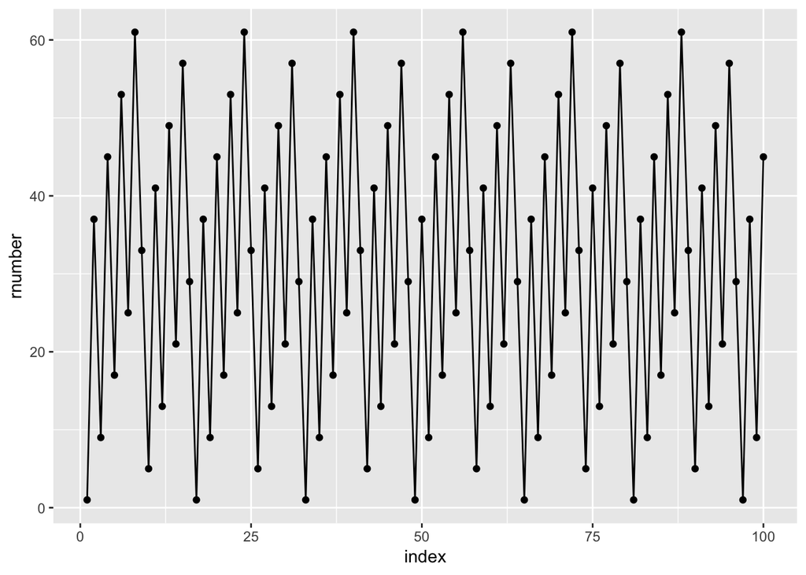

```r
p <- random_numbers %>%
  data.frame(rnumber = ., index = 1:length(random_numbers)) %>%
  ggplot(aes(x = index, y = rnumber)) +
  geom_point() +
  geom_line()

print(p)
```

- The numbers are clearly not random!
- Lets try with parameter c = 5:

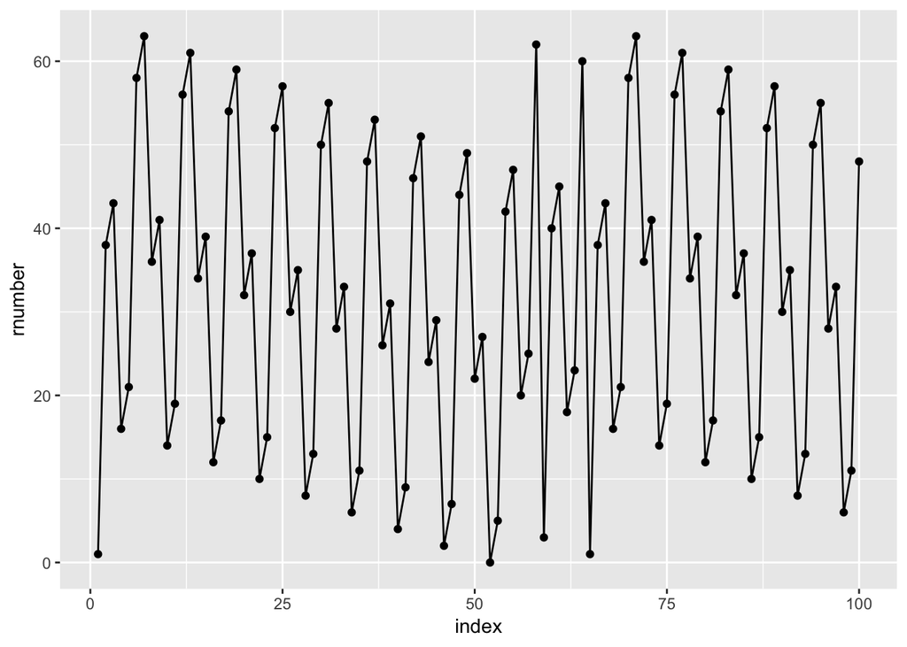

```r
random_numbers <- rng(1, 100, 64, 33, 5)


p <- random_numbers %>%
  data.frame(rnumber = ., index = 1:length(random_numbers)) %>%
  ggplot(aes(x = index, y = rnumber)) +
  geom_point() +
  geom_line()

print(p)
```

- More randomness appears but still not impressively random. Now as c = 5 the cycle length becomes $2^6 = 64$.
- With even different parameters:

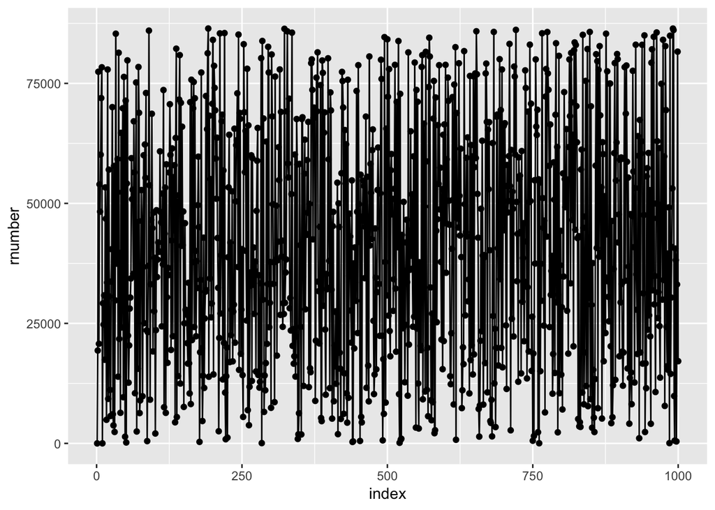

```r
random_numbers <- rng(1, 1000, 86436, 1093, 18257)


p <- random_numbers %>%
  data.frame(rnumber = ., index = 1:length(random_numbers)) %>%
  ggplot(aes(x = index, y = rnumber)) +
  geom_point() +
  geom_line()

print(p)
```

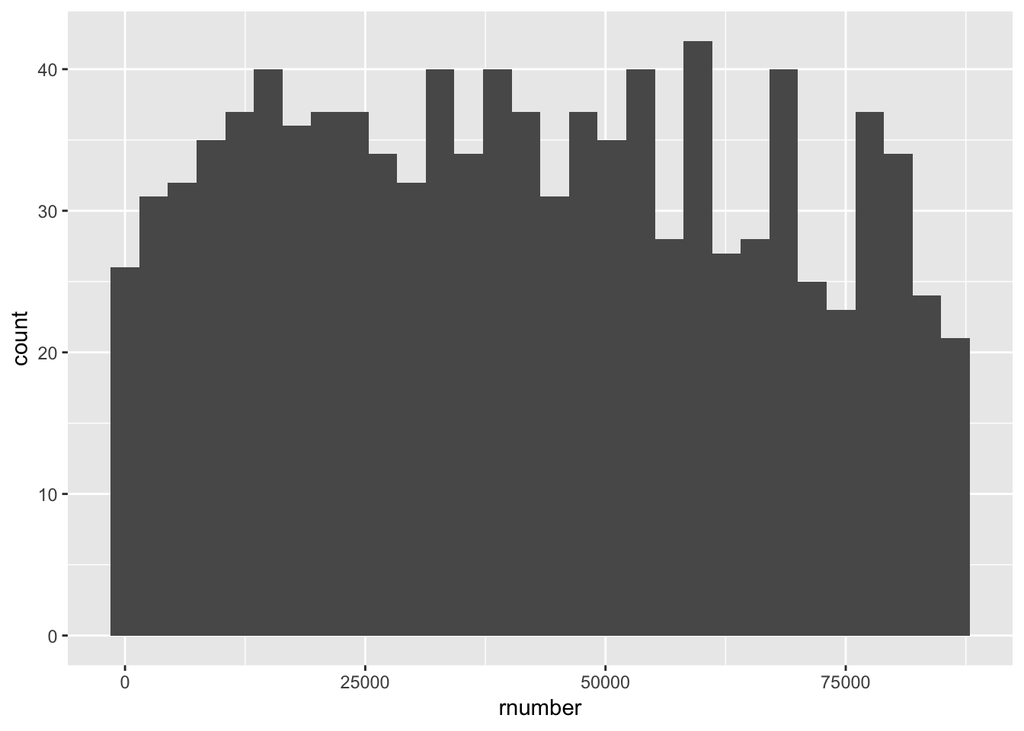

```r
histogram <- random_numbers %>%
  data.frame(rnumber = ., index = 1:length(random_numbers)) %>%
  ggplot(aes(x = rnumber)) +
  geom_histogram()


histogram
```

- The trace plot looks very random but the histogram leaves room for doubt. Ideally with more generated numbers we would expect a more or less uniform distribution as all values are equally likely. This however is not enough as the order a histogram doesn’t tell anything about the order in which the numbers were generated.
- Let’s try the generator with even more numbers:

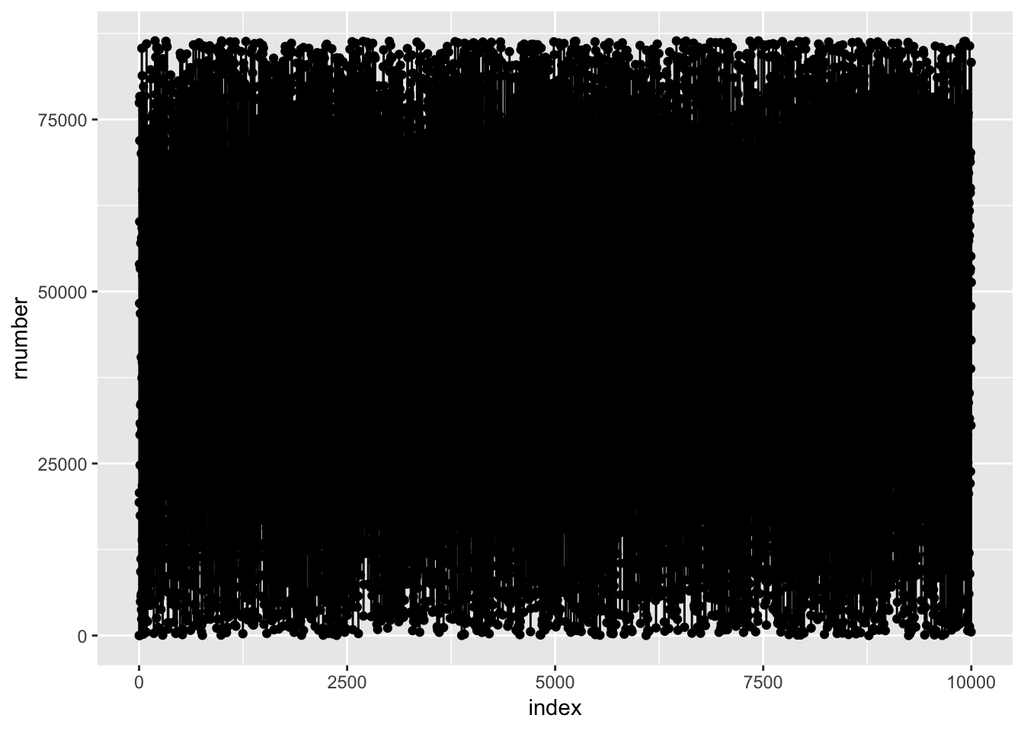

```r
random_numbers <- rng(1, 10000, 86436, 1093, 18257)


p <- random_numbers %>%
  data.frame(rnumber = ., index = 1:length(random_numbers)) %>%
  ggplot(aes(x = index, y = rnumber)) +
  geom_point() +
  geom_line()

print(p)
```

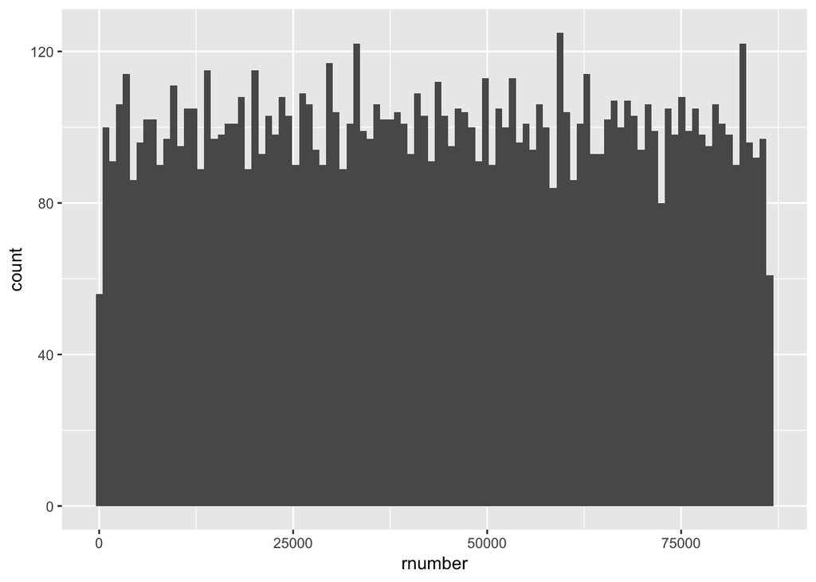

```r
histogram <- random_numbers %>%
  data.frame(rnumber = ., index = 1:length(random_numbers)) %>%
  ggplot(aes(x = rnumber)) +
  geom_histogram(bins = 100)


histogram
```

- Very random indeed.